# Risk Factor Analysis

## Outcome Variable

**Outcome Variable:** y_rate_len

## Predictor Variables

**Intervention Variable:** gagebrth

**Adjustment Set:**

- arm
- sex
- W_mage
- meducyrs
- feducyrs
- W_mhtcm
- single
- brthmon
- W_parity
- delta_W_mage
- delta_meducyrs
- delta_feducyrs
- delta_W_mhtcm
- delta_single
- delta_brthmon
- delta_W_parity

## Stratifying Variables

The analysis was stratified on these variable(s):

- agecat
- studyid
- country

## Data Summary

| agecat | studyid | country | gagebrth | n_cell | n |
| --- | --- | --- | --- | --- | --- |
| 0-3 months | ki1017093c-NIH-Crypto | BANGLADESH | [273-287) | 239 | 720 |
| 0-3 months | ki1017093c-NIH-Crypto | BANGLADESH | <259 | 148 | 720 |
| 0-3 months | ki1017093c-NIH-Crypto | BANGLADESH | [259-273) | 315 | 720 |
| 0-3 months | ki1017093c-NIH-Crypto | BANGLADESH | >=287 | 18 | 720 |
| 0-3 months | kiGH5241-JiVitA-3 | BANGLADESH | [273-287) | 5937 | 16862 |
| 0-3 months | kiGH5241-JiVitA-3 | BANGLADESH | <259 | 3173 | 16862 |
| 0-3 months | kiGH5241-JiVitA-3 | BANGLADESH | [259-273) | 4445 | 16862 |
| 0-3 months | kiGH5241-JiVitA-3 | BANGLADESH | >=287 | 3307 | 16862 |
| 0-3 months | ki1119695-PROBIT | BELARUS | [273-287) | 9366 | 12745 |
| 0-3 months | ki1119695-PROBIT | BELARUS | [259-273) | 2363 | 12745 |
| 0-3 months | ki1119695-PROBIT | BELARUS | >=287 | 1016 | 12745 |
| 0-3 months | ki1101329-Keneba | GAMBIA | [273-287) | 478 | 1232 |
| 0-3 months | ki1101329-Keneba | GAMBIA | <259 | 125 | 1232 |
| 0-3 months | ki1101329-Keneba | GAMBIA | [259-273) | 488 | 1232 |
| 0-3 months | ki1101329-Keneba | GAMBIA | >=287 | 141 | 1232 |
| 0-3 months | ki1135781-COHORTS | GUATEMALA | [273-287) | 224 | 551 |
| 0-3 months | ki1135781-COHORTS | GUATEMALA | <259 | 69 | 551 |
| 0-3 months | ki1135781-COHORTS | GUATEMALA | [259-273) | 79 | 551 |
| 0-3 months | ki1135781-COHORTS | GUATEMALA | >=287 | 179 | 551 |
| 0-3 months | ki1000108-CMC-V-BCS-2002 | INDIA | [273-287) | 34 | 86 |
| 0-3 months | ki1000108-CMC-V-BCS-2002 | INDIA | <259 | 8 | 86 |
| 0-3 months | ki1000108-CMC-V-BCS-2002 | INDIA | [259-273) | 21 | 86 |
| 0-3 months | ki1000108-CMC-V-BCS-2002 | INDIA | >=287 | 23 | 86 |
| 0-3 months | ki1000108-IRC | INDIA | [273-287) | 151 | 359 |
| 0-3 months | ki1000108-IRC | INDIA | <259 | 36 | 359 |
| 0-3 months | ki1000108-IRC | INDIA | [259-273) | 85 | 359 |
| 0-3 months | ki1000108-IRC | INDIA | >=287 | 87 | 359 |
| 0-3 months | ki1000304b-SAS-CompFeed | INDIA | [273-287) | 32 | 1161 |
| 0-3 months | ki1000304b-SAS-CompFeed | INDIA | <259 | 926 | 1161 |
| 0-3 months | ki1000304b-SAS-CompFeed | INDIA | [259-273) | 202 | 1161 |

[output cut: 140 more lines]

The following strata were considered:

- agecat: 0-3 months, studyid: ki1000108-CMC-V-BCS-2002, country: INDIA
- agecat: 0-3 months, studyid: ki1000108-IRC, country: INDIA
- agecat: 0-3 months, studyid: ki1000109-EE, country: PAKISTAN
- agecat: 0-3 months, studyid: ki1000304b-SAS-CompFeed, country: INDIA
- agecat: 0-3 months, studyid: ki1017093c-NIH-Crypto, country: BANGLADESH
- agecat: 0-3 months, studyid: ki1101329-Keneba, country: GAMBIA
- agecat: 0-3 months, studyid: ki1119695-PROBIT, country: BELARUS
- agecat: 0-3 months, studyid: ki1135781-COHORTS, country: GUATEMALA
- agecat: 0-3 months, studyid: ki1135781-COHORTS, country: INDIA
- agecat: 0-3 months, studyid: kiGH5241-JiVitA-3, country: BANGLADESH
- agecat: 12-24 months, studyid: ki1000108-CMC-V-BCS-2002, country: INDIA
- agecat: 12-24 months, studyid: ki1000108-IRC, country: INDIA
- agecat: 12-24 months, studyid: ki1017093c-NIH-Crypto, country: BANGLADESH
- agecat: 12-24 months, studyid: ki1066203-TanzaniaChild2, country: TANZANIA, UNITED REPUBLIC OF
- agecat: 12-24 months, studyid: ki1101329-Keneba, country: GAMBIA
- agecat: 12-24 months, studyid: ki1113344-GMS-Nepal, country: NEPAL
- agecat: 12-24 months, studyid: ki1119695-PROBIT, country: BELARUS
- agecat: 12-24 months, studyid: ki1135781-COHORTS, country: GUATEMALA
- agecat: 12-24 months, studyid: ki1135781-COHORTS, country: INDIA
- agecat: 12-24 months, studyid: ki1135781-COHORTS, country: PHILIPPINES
- agecat: 12-24 months, studyid: kiGH5241-JiVitA-3, country: BANGLADESH
- agecat: 3-6 months, studyid: ki1000108-CMC-V-BCS-2002, country: INDIA
- agecat: 3-6 months, studyid: ki1000108-IRC, country: INDIA
- agecat: 3-6 months, studyid: ki1000109-EE, country: PAKISTAN
- agecat: 3-6 months, studyid: ki1000304b-SAS-CompFeed, country: INDIA
- agecat: 3-6 months, studyid: ki1017093c-NIH-Crypto, country: BANGLADESH
- agecat: 3-6 months, studyid: ki1066203-TanzaniaChild2, country: TANZANIA, UNITED REPUBLIC OF
- agecat: 3-6 months, studyid: ki1101329-Keneba, country: GAMBIA
- agecat: 3-6 months, studyid: ki1113344-GMS-Nepal, country: NEPAL
- agecat: 3-6 months, studyid: ki1119695-PROBIT, country: BELARUS
- agecat: 3-6 months, studyid: ki1135781-COHORTS, country: GUATEMALA
- agecat: 3-6 months, studyid: ki1135781-COHORTS, country: INDIA
- agecat: 3-6 months, studyid: kiGH5241-JiVitA-3, country: BANGLADESH
- agecat: 6-12 months, studyid: ki1000108-CMC-V-BCS-2002, country: INDIA
- agecat: 6-12 months, studyid: ki1000108-IRC, country: INDIA
- agecat: 6-12 months, studyid: ki1000109-EE, country: PAKISTAN
- agecat: 6-12 months, studyid: ki1000304b-SAS-CompFeed, country: INDIA
- agecat: 6-12 months, studyid: ki1017093c-NIH-Crypto, country: BANGLADESH
- agecat: 6-12 months, studyid: ki1066203-TanzaniaChild2, country: TANZANIA, UNITED REPUBLIC OF
- agecat: 6-12 months, studyid: ki1101329-Keneba, country: GAMBIA
- agecat: 6-12 months, studyid: ki1113344-GMS-Nepal, country: NEPAL
- agecat: 6-12 months, studyid: ki1119695-PROBIT, country: BELARUS
- agecat: 6-12 months, studyid: ki1135781-COHORTS, country: GUATEMALA
- agecat: 6-12 months, studyid: ki1135781-COHORTS, country: INDIA
- agecat: 6-12 months, studyid: ki1135781-COHORTS, country: PHILIPPINES
- agecat: 6-12 months, studyid: kiGH5241-JiVitA-3, country: BANGLADESH

### Dropped Strata

Some strata were dropped due to rare outcomes:

- agecat: 0-3 months, studyid: ki1000304b-SAS-CompFeed, country: INDIA
- agecat: 0-3 months, studyid: ki1000109-EE, country: PAKISTAN
- agecat: 3-6 months, studyid: ki1000304b-SAS-CompFeed, country: INDIA
- agecat: 3-6 months, studyid: ki1113344-GMS-Nepal, country: NEPAL
- agecat: 3-6 months, studyid: ki1000109-EE, country: PAKISTAN
- agecat: 6-12 months, studyid: ki1000304b-SAS-CompFeed, country: INDIA
- agecat: 6-12 months, studyid: ki1113344-GMS-Nepal, country: NEPAL
- agecat: 6-12 months, studyid: ki1000109-EE, country: PAKISTAN
- agecat: 12-24 months, studyid: ki1113344-GMS-Nepal, country: NEPAL
- agecat: 12-24 months, studyid: ki1066203-TanzaniaChild2, country: TANZANIA, UNITED REPUBLIC OF

## Methods Detail

We’re interested in the causal parameters $E[Y_a]$ for all values of $a \in \mathcal{A}$. These parameters represent the mean outcome if, possibly contrary to fact, we intervened to set all units to have $A=a$. Under the randomization and positivity assumptions, these are identified by the statistical parameters $\psi_a=E_W[E_{Y|A,W}(Y|A=a,W)]$. In addition, we’re interested in the mean of $Y$, $E[Y]$ under no intervention (the observed mean). We will estimate these parameters by using SuperLearner to fit the relevant likelihood factors – $E_{Y|A,W}(Y|A=a,W)$ and $p(A=a|W)$, and then updating our likelihood fit using a joint TMLE.

For unadjusted analyses ($W=\{\}$), initial likelihoods were estimated using Lrnr_glm to estimate the simple $E(Y|A)$ and Lrnr_mean to estimate $p(A)$. For adjusted analyses, a small library containing Lrnr_glmnet, Lrnr_xgboost, and Lrnr_mean was used.

Having estimated these parameters, we will then use the delta method to estimate relative risks and attributable risks relative to a prespecified baseline level of $A$.

[output not shown]

[output not shown]

[output not shown]

[output not shown]

# Results Detail

## Results Plots

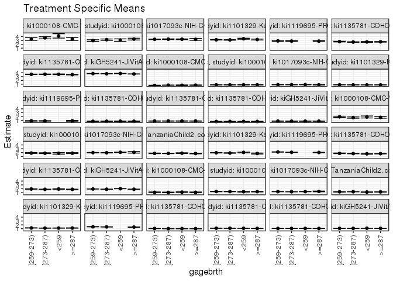

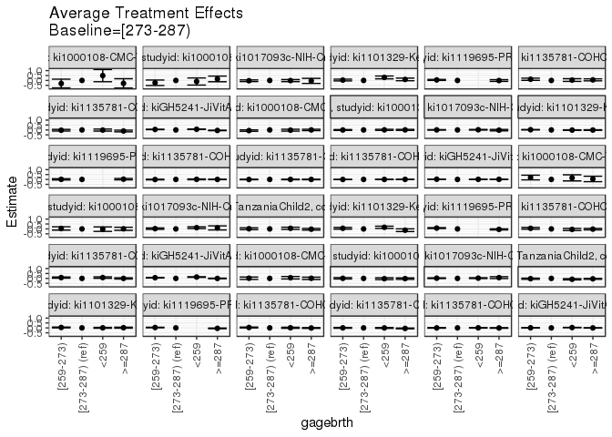

## Results Table

### Parameter: TSM

| agecat | studyid | country | intervention_level | baseline_level | estimate | ci_lower | ci_upper |
| --- | --- | --- | --- | --- | --- | --- | --- |
| 0-3 months | ki1000108-CMC-V-BCS-2002 | INDIA | [273-287) | NA | 3.6802487 | 3.4062808 | 3.9542166 |
| 0-3 months | ki1000108-CMC-V-BCS-2002 | INDIA | <259 | NA | 4.1739005 | 3.6123605 | 4.7354405 |
| 0-3 months | ki1000108-CMC-V-BCS-2002 | INDIA | [259-273) | NA | 3.3686460 | 3.0212781 | 3.7160138 |
| 0-3 months | ki1000108-CMC-V-BCS-2002 | INDIA | >=287 | NA | 3.3841145 | 3.0002609 | 3.7679681 |
| 0-3 months | ki1000108-IRC | INDIA | [273-287) | NA | 3.1897507 | 3.0124027 | 3.3670986 |
| 0-3 months | ki1000108-IRC | INDIA | <259 | NA | 3.0824599 | 2.7663874 | 3.3985325 |
| 0-3 months | ki1000108-IRC | INDIA | [259-273) | NA | 2.9552233 | 2.7407802 | 3.1696665 |
| 0-3 months | ki1000108-IRC | INDIA | >=287 | NA | 3.3454432 | 3.1181834 | 3.5727030 |
| 0-3 months | ki1017093c-NIH-Crypto | BANGLADESH | [273-287) | NA | 3.3261995 | 3.2572986 | 3.3951004 |
| 0-3 months | ki1017093c-NIH-Crypto | BANGLADESH | <259 | NA | 3.3106640 | 3.2310332 | 3.3902949 |
| 0-3 months | ki1017093c-NIH-Crypto | BANGLADESH | [259-273) | NA | 3.2947852 | 3.2393481 | 3.3502223 |
| 0-3 months | ki1017093c-NIH-Crypto | BANGLADESH | >=287 | NA | 3.2808162 | 3.0313357 | 3.5302967 |
| 0-3 months | ki1101329-Keneba | GAMBIA | [273-287) | NA | 3.1302947 | 3.0627966 | 3.1977927 |
| 0-3 months | ki1101329-Keneba | GAMBIA | <259 | NA | 3.4384914 | 3.3087421 | 3.5682408 |
| 0-3 months | ki1101329-Keneba | GAMBIA | [259-273) | NA | 3.1702932 | 3.1060728 | 3.2345136 |
| 0-3 months | ki1101329-Keneba | GAMBIA | >=287 | NA | 3.2341868 | 3.1150627 | 3.3533109 |
| 0-3 months | ki1119695-PROBIT | BELARUS | [273-287) | NA | 2.8293367 | 2.7135768 | 2.9450966 |
| 0-3 months | ki1119695-PROBIT | BELARUS | [259-273) | NA | 2.8815903 | 2.7574138 | 3.0057668 |
| 0-3 months | ki1119695-PROBIT | BELARUS | >=287 | NA | 2.8177820 | 2.7083647 | 2.9271993 |
| 0-3 months | ki1135781-COHORTS | GUATEMALA | [273-287) | NA | 2.5765990 | 2.5066111 | 2.6465870 |
| 0-3 months | ki1135781-COHORTS | GUATEMALA | <259 | NA | 2.6151735 | 2.4957608 | 2.7345862 |
| 0-3 months | ki1135781-COHORTS | GUATEMALA | [259-273) | NA | 2.6983327 | 2.6080202 | 2.7886451 |
| 0-3 months | ki1135781-COHORTS | GUATEMALA | >=287 | NA | 2.6354514 | 2.5572962 | 2.7136065 |
| 0-3 months | ki1135781-COHORTS | INDIA | [273-287) | NA | 3.6023755 | 3.5487481 | 3.6560029 |
| 0-3 months | ki1135781-COHORTS | INDIA | <259 | NA | 3.5880928 | 3.4997797 | 3.6764058 |
| 0-3 months | ki1135781-COHORTS | INDIA | [259-273) | NA | 3.5727672 | 3.5078823 | 3.6376521 |
| 0-3 months | ki1135781-COHORTS | INDIA | >=287 | NA | 3.4936751 | 3.4280710 | 3.5592792 |
| 0-3 months | kiGH5241-JiVitA-3 | BANGLADESH | [273-287) | NA | 3.7226125 | 3.7073019 | 3.7379231 |
| 0-3 months | kiGH5241-JiVitA-3 | BANGLADESH | <259 | NA | 3.7918299 | 3.7705438 | 3.8131159 |
| 0-3 months | kiGH5241-JiVitA-3 | BANGLADESH | [259-273) | NA | 3.7718666 | 3.7537390 | 3.7899941 |

[output cut: 110 more lines]

### Parameter: E(Y)

| agecat | studyid | country | intervention_level | baseline_level | estimate | ci_lower | ci_upper |
| --- | --- | --- | --- | --- | --- | --- | --- |
| 0-3 months | ki1000108-CMC-V-BCS-2002 | INDIA | NA | NA | 3.5424620 | 3.3226559 | 3.7622681 |
| 0-3 months | ki1000108-IRC | INDIA | NA | NA | 3.1786708 | 3.0648748 | 3.2924667 |
| 0-3 months | ki1017093c-NIH-Crypto | BANGLADESH | NA | NA | 3.3028656 | 3.2646714 | 3.3410598 |
| 0-3 months | ki1101329-Keneba | GAMBIA | NA | NA | 3.1443710 | 3.0969764 | 3.1917656 |
| 0-3 months | ki1119695-PROBIT | BELARUS | NA | NA | 2.8355739 | 2.7218468 | 2.9493011 |
| 0-3 months | ki1135781-COHORTS | GUATEMALA | NA | NA | 2.6275446 | 2.5773487 | 2.6777405 |
| 0-3 months | ki1135781-COHORTS | INDIA | NA | NA | 3.5676089 | 3.5348954 | 3.6003223 |
| 0-3 months | kiGH5241-JiVitA-3 | BANGLADESH | NA | NA | 3.7366791 | 3.7256757 | 3.7476826 |
| 3-6 months | ki1000108-CMC-V-BCS-2002 | INDIA | NA | NA | 1.8085894 | 1.7027345 | 1.9144443 |
| 3-6 months | ki1000108-IRC | INDIA | NA | NA | 1.8770590 | 1.8115784 | 1.9425395 |
| 3-6 months | ki1017093c-NIH-Crypto | BANGLADESH | NA | NA | 2.0057973 | 1.9693775 | 2.0422170 |
| 3-6 months | ki1066203-TanzaniaChild2 | TANZANIA, UNITED REPUBLIC OF | NA | NA | 1.7930234 | 1.7563473 | 1.8296994 |
| 3-6 months | ki1101329-Keneba | GAMBIA | NA | NA | 1.9509973 | 1.9060862 | 1.9959083 |
| 3-6 months | ki1119695-PROBIT | BELARUS | NA | NA | 2.0914863 | 2.0503474 | 2.1326251 |
| 3-6 months | ki1135781-COHORTS | GUATEMALA | NA | NA | 1.7551575 | 1.7203355 | 1.7899795 |
| 3-6 months | ki1135781-COHORTS | INDIA | NA | NA | 1.8699710 | 1.8423785 | 1.8975635 |
| 3-6 months | kiGH5241-JiVitA-3 | BANGLADESH | NA | NA | 1.9120583 | 1.8998349 | 1.9242816 |
| 6-12 months | ki1000108-CMC-V-BCS-2002 | INDIA | NA | NA | 1.0679211 | 1.0201335 | 1.1157087 |
| 6-12 months | ki1000108-IRC | INDIA | NA | NA | 1.2481465 | 1.2180063 | 1.2782868 |
| 6-12 months | ki1017093c-NIH-Crypto | BANGLADESH | NA | NA | 1.2281313 | 1.2106849 | 1.2455776 |
| 6-12 months | ki1066203-TanzaniaChild2 | TANZANIA, UNITED REPUBLIC OF | NA | NA | 1.1945105 | 1.1722780 | 1.2167429 |
| 6-12 months | ki1101329-Keneba | GAMBIA | NA | NA | 1.1776266 | 1.1570262 | 1.1982270 |
| 6-12 months | ki1119695-PROBIT | BELARUS | NA | NA | 1.4709224 | 1.4326640 | 1.5091808 |
| 6-12 months | ki1135781-COHORTS | GUATEMALA | NA | NA | 1.0213263 | 1.0014497 | 1.0412028 |
| 6-12 months | ki1135781-COHORTS | INDIA | NA | NA | 1.1028264 | 1.0847215 | 1.1209313 |
| 6-12 months | ki1135781-COHORTS | PHILIPPINES | NA | NA | 1.0678997 | 1.0556267 | 1.0801728 |
| 6-12 months | kiGH5241-JiVitA-3 | BANGLADESH | NA | NA | 1.1011985 | 1.0937157 | 1.1086814 |
| 12-24 months | ki1000108-CMC-V-BCS-2002 | INDIA | NA | NA | 0.7386817 | 0.7107419 | 0.7666215 |
| 12-24 months | ki1000108-IRC | INDIA | NA | NA | 0.8299611 | 0.8097588 | 0.8501634 |
| 12-24 months | ki1017093c-NIH-Crypto | BANGLADESH | NA | NA | 0.8755729 | 0.8637860 | 0.8873598 |
| 12-24 months | ki1101329-Keneba | GAMBIA | NA | NA | 0.8441456 | 0.8319594 | 0.8563317 |
| 12-24 months | ki1119695-PROBIT | BELARUS | NA | NA | 0.8601486 | 0.8069287 | 0.9133686 |
| 12-24 months | ki1135781-COHORTS | GUATEMALA | NA | NA | 0.7708974 | 0.7583131 | 0.7834816 |
| 12-24 months | ki1135781-COHORTS | INDIA | NA | NA | 0.8282794 | 0.8184657 | 0.8380931 |
| 12-24 months | ki1135781-COHORTS | PHILIPPINES | NA | NA | 0.7066944 | 0.6993116 | 0.7140773 |
| 12-24 months | kiGH5241-JiVitA-3 | BANGLADESH | NA | NA | 0.7935866 | 0.7876461 | 0.7995270 |

### Parameter: ATE

| agecat | studyid | country | intervention_level | baseline_level | estimate | ci_lower | ci_upper |
| --- | --- | --- | --- | --- | --- | --- | --- |
| 0-3 months | ki1000108-CMC-V-BCS-2002 | INDIA | [273-287) | [273-287) | 0.0000000 | 0.0000000 | 0.0000000 |
| 0-3 months | ki1000108-CMC-V-BCS-2002 | INDIA | <259 | [273-287) | 0.4936518 | -0.1283159 | 1.1156195 |
| 0-3 months | ki1000108-CMC-V-BCS-2002 | INDIA | [259-273) | [273-287) | -0.3116027 | -0.7536342 | 0.1304287 |
| 0-3 months | ki1000108-CMC-V-BCS-2002 | INDIA | >=287 | [273-287) | -0.2961342 | -0.7682269 | 0.1759585 |
| 0-3 months | ki1000108-IRC | INDIA | [273-287) | [273-287) | 0.0000000 | 0.0000000 | 0.0000000 |
| 0-3 months | ki1000108-IRC | INDIA | <259 | [273-287) | -0.1072908 | -0.4696076 | 0.2550261 |
| 0-3 months | ki1000108-IRC | INDIA | [259-273) | [273-287) | -0.2345274 | -0.5123912 | 0.0433365 |
| 0-3 months | ki1000108-IRC | INDIA | >=287 | [273-287) | 0.1556925 | -0.1318021 | 0.4431871 |
| 0-3 months | ki1017093c-NIH-Crypto | BANGLADESH | [273-287) | [273-287) | 0.0000000 | 0.0000000 | 0.0000000 |
| 0-3 months | ki1017093c-NIH-Crypto | BANGLADESH | <259 | [273-287) | -0.0155355 | -0.1204026 | 0.0893317 |
| 0-3 months | ki1017093c-NIH-Crypto | BANGLADESH | [259-273) | [273-287) | -0.0314143 | -0.1191846 | 0.0563560 |
| 0-3 months | ki1017093c-NIH-Crypto | BANGLADESH | >=287 | [273-287) | -0.0453833 | -0.3040246 | 0.2132580 |
| 0-3 months | ki1101329-Keneba | GAMBIA | [273-287) | [273-287) | 0.0000000 | 0.0000000 | 0.0000000 |
| 0-3 months | ki1101329-Keneba | GAMBIA | <259 | [273-287) | 0.3081968 | 0.1638479 | 0.4525457 |
| 0-3 months | ki1101329-Keneba | GAMBIA | [259-273) | [273-287) | 0.0399985 | -0.0496993 | 0.1296963 |
| 0-3 months | ki1101329-Keneba | GAMBIA | >=287 | [273-287) | 0.1038921 | -0.0305449 | 0.2383292 |
| 0-3 months | ki1119695-PROBIT | BELARUS | [273-287) | [273-287) | 0.0000000 | 0.0000000 | 0.0000000 |
| 0-3 months | ki1119695-PROBIT | BELARUS | [259-273) | [273-287) | 0.0522536 | -0.0012662 | 0.1057734 |
| 0-3 months | ki1119695-PROBIT | BELARUS | >=287 | [273-287) | -0.0115547 | -0.1006096 | 0.0775002 |
| 0-3 months | ki1135781-COHORTS | GUATEMALA | [273-287) | [273-287) | 0.0000000 | 0.0000000 | 0.0000000 |
| 0-3 months | ki1135781-COHORTS | GUATEMALA | <259 | [273-287) | 0.0385745 | -0.0986665 | 0.1758154 |
| 0-3 months | ki1135781-COHORTS | GUATEMALA | [259-273) | [273-287) | 0.1217337 | 0.0088283 | 0.2346391 |
| 0-3 months | ki1135781-COHORTS | GUATEMALA | >=287 | [273-287) | 0.0588523 | -0.0444393 | 0.1621440 |
| 0-3 months | ki1135781-COHORTS | INDIA | [273-287) | [273-287) | 0.0000000 | 0.0000000 | 0.0000000 |
| 0-3 months | ki1135781-COHORTS | INDIA | <259 | [273-287) | -0.0142827 | -0.1175919 | 0.0890265 |
| 0-3 months | ki1135781-COHORTS | INDIA | [259-273) | [273-287) | -0.0296083 | -0.1137713 | 0.0545548 |
| 0-3 months | ki1135781-COHORTS | INDIA | >=287 | [273-287) | -0.1087004 | -0.1934175 | -0.0239832 |
| 0-3 months | kiGH5241-JiVitA-3 | BANGLADESH | [273-287) | [273-287) | 0.0000000 | 0.0000000 | 0.0000000 |
| 0-3 months | kiGH5241-JiVitA-3 | BANGLADESH | <259 | [273-287) | 0.0692174 | 0.0444269 | 0.0940078 |
| 0-3 months | kiGH5241-JiVitA-3 | BANGLADESH | [259-273) | [273-287) | 0.0492541 | 0.0277065 | 0.0708017 |

[output cut: 110 more lines]